# Titanic EDA: Signal in Cabin, Fare, and Embarkation

Author

CLI Copilot

# Introduction

This report investigates three research questions regarding the Titanic dataset: 1. Does cabin and deck information add signal beyond class and fare? 2. Is fare a proxy for wealth within class or does it carry independent survival signal? 3. Does the port of embarkation change survival patterns after controlling for who boards there?

For each question, we perform exploratory data analysis (EDA) and modeling, providing detailed explanations for every step and code chunk.

# Data and Setup

```r
library(tidyverse)
library(ggplot2)
library(knitr)
train <- read_csv("../../data/train.csv")
test <- read_csv("../../data/test.csv")
```

We load the required libraries and read the training and test datasets. The `tidyverse` and `ggplot2` packages are used for data manipulation and visualization, while `knitr` is used for consistent table formatting. The data files are loaded from the `data/` directory as described in the project instructions.

# 1. Cabin and Deck Information Beyond Class and Fare

## 1.1 Extract Deck from Cabin and Compare Survival by Deck

```r
train <- train %>% mutate(
  Deck = substr(Cabin, 1, 1),
  MissingCabin = is.na(Cabin)
)
```

We extract the deck by taking the first letter of the `Cabin` variable and create a `MissingCabin` indicator. This allows us to analyze survival rates by deck and by whether cabin information is missing, which may reveal additional signal beyond class and fare.

## 1.2 Survival by Deck and MissingCabin, Stratified by Pclass

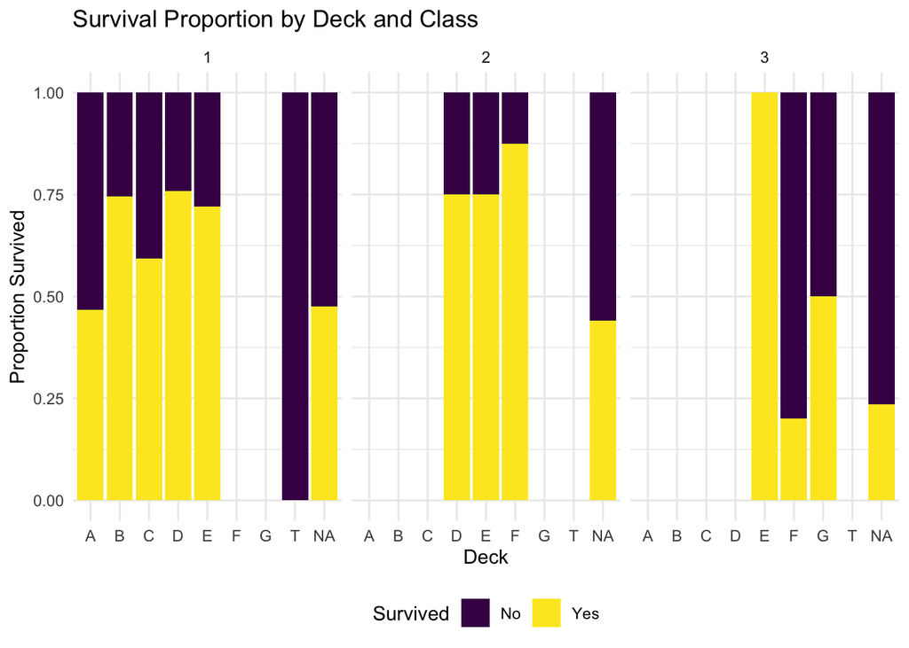

```r
ggplot(train, aes(x = Deck, fill = factor(Survived))) +
  geom_bar(position = 'fill') +
  facet_wrap(~Pclass) +
  scale_fill_viridis_d(name = "Survived", labels = c("No", "Yes")) +
  labs(title = "Survival Proportion by Deck and Class", x = "Deck", y = "Proportion Survived") +
  theme_minimal() +
  theme(legend.position = "bottom")
```

This plot shows the proportion of survivors by deck, stratified by passenger class. Using a fill proportion bar plot allows us to compare survival rates across decks and classes, helping to determine if deck adds signal beyond class.

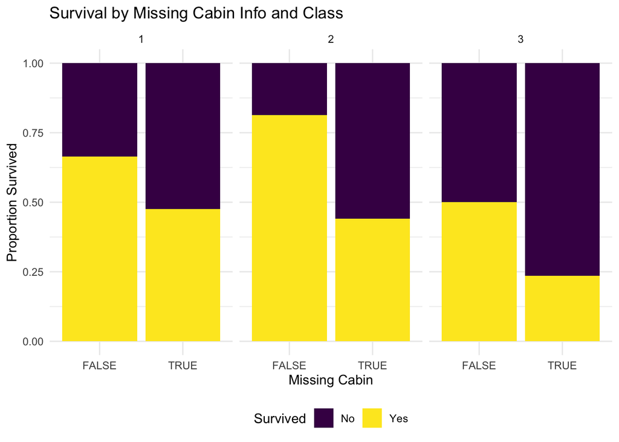

```r
ggplot(train, aes(x = factor(MissingCabin), fill = factor(Survived))) +
  geom_bar(position = 'fill') +
  facet_wrap(~Pclass) +
  scale_fill_viridis_d(name = "Survived", labels = c("No", "Yes")) +
  labs(title = "Survival by Missing Cabin Info and Class", x = "Missing Cabin", y = "Proportion Survived") +
  theme_minimal() +
  theme(legend.position = "bottom")
```

This plot examines whether missing cabin information is associated with survival, stratified by class. This helps assess if the absence of cabin data itself is informative.

## 1.3 Model: Add Deck and MissingCabin, Measure Gain and Feature Importance

```r
library(caret)
set.seed(42)
train$Deck <- as.factor(train$Deck)
train$MissingCabin <- as.factor(train$MissingCabin)
model1 <- train(factor(Survived) ~ Pclass + Fare, data = train, method = "glm", family = "binomial", trControl = trainControl(method = "cv", number = 5), na.action = na.omit)
model2 <- train(factor(Survived) ~ Pclass + Fare + Deck + MissingCabin, data = train, method = "glm", family = "binomial", trControl = trainControl(method = "cv", number = 5), na.action = na.omit)
cv_gain <- model2$results$Accuracy - model1$results$Accuracy
imp <- varImp(model2)
cv_gain
```

```
[1] -0.03087548
```

```r
imp
```

```
glm variable importance

        Overall
Fare   100.0000
DeckD   98.5335
DeckE   97.6809
DeckB   76.6926
DeckF   38.2640
DeckC   17.7847
DeckG    9.9476
DeckT    0.3327
Pclass   0.0000
```

We fit two logistic regression models: one with only class and fare, and another adding deck and missing cabin. We compare cross-validation accuracy and inspect feature importance to determine if deck and missing cabin add predictive value.

# 2. Is Fare a Proxy for Wealth Within Class?

## 2.1 Plot Survival vs Fare Within Each Pclass

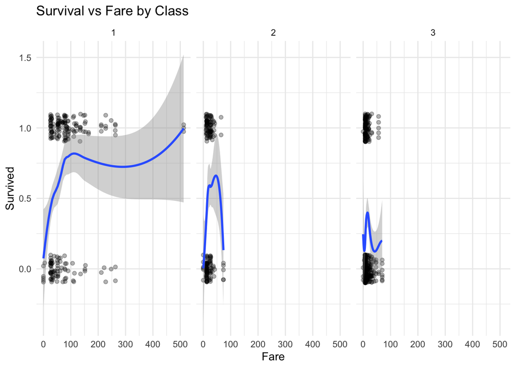

```r
ggplot(train, aes(x = Fare, y = Survived)) +
  geom_jitter(height = 0.1, alpha = 0.3) +
  geom_smooth(method = "loess") +
  facet_wrap(~Pclass) +
  labs(title = "Survival vs Fare by Class", x = "Fare", y = "Survived") +
  theme_minimal() +
  theme(legend.position = "bottom")
```

This plot visualizes the relationship between fare and survival within each class, helping to determine if fare carries signal beyond class.

## 2.2 Compare Fare Quantiles per Class

```r
train <- train %>% group_by(Pclass) %>% mutate(FareQuantileWithinClass = ntile(Fare, 4))
train %>% group_by(Pclass, FareQuantileWithinClass) %>% summarise(SurvivalRate = mean(Survived), n = n()) %>% kable()
```

| Pclass | FareQuantileWithinClass | SurvivalRate | n |
| --- | --- | --- | --- |
| 1 | 1 | 0.4629630 | 54 |
| 1 | 2 | 0.5740741 | 54 |
| 1 | 3 | 0.7407407 | 54 |
| 1 | 4 | 0.7407407 | 54 |
| 2 | 1 | 0.3478261 | 46 |
| 2 | 2 | 0.3695652 | 46 |
| 2 | 3 | 0.6521739 | 46 |
| 2 | 4 | 0.5217391 | 46 |
| 3 | 1 | 0.2276423 | 123 |
| 3 | 2 | 0.2195122 | 123 |
| 3 | 3 | 0.2439024 | 123 |
| 3 | 4 | 0.2786885 | 122 |

We create fare quantiles within each class and summarize survival rates by quantile. This table helps assess whether higher fare within class is associated with higher survival.

## 2.3 Model: Use log1p(Fare) and FareQuantileWithinClass

```r
train$logFare <- log1p(train$Fare)
train$FareQuantileWithinClass <- as.factor(train$FareQuantileWithinClass)
model3 <- train(factor(Survived) ~ Pclass, data = train, method = "glm", family = "binomial", trControl = trainControl(method = "cv", number = 5), na.action = na.omit)
model4 <- train(factor(Survived) ~ Pclass + logFare + FareQuantileWithinClass, data = train, method = "glm", family = "binomial", trControl = trainControl(method = "cv", number = 5), na.action = na.omit)
cv_gain_fare <- model4$results$Accuracy - model3$results$Accuracy
imp_fare <- varImp(model4)
cv_gain_fare
```

```
[1] 0.01243754
```

```r
imp_fare
```

```
glm variable importance

                         Overall
Pclass                   100.000
logFare                   76.007
FareQuantileWithinClass3  40.593
FareQuantileWithinClass2   2.758
FareQuantileWithinClass4   0.000
```

We compare a model with only class to one that adds log-transformed fare and fare quantile within class. The cross-validation gain and feature importance indicate whether fare adds independent signal.

# 3. Does Port of Embarkation Change Survival Patterns?

## 3.1 Survival by Embarked, Then Condition on Pclass and Sex

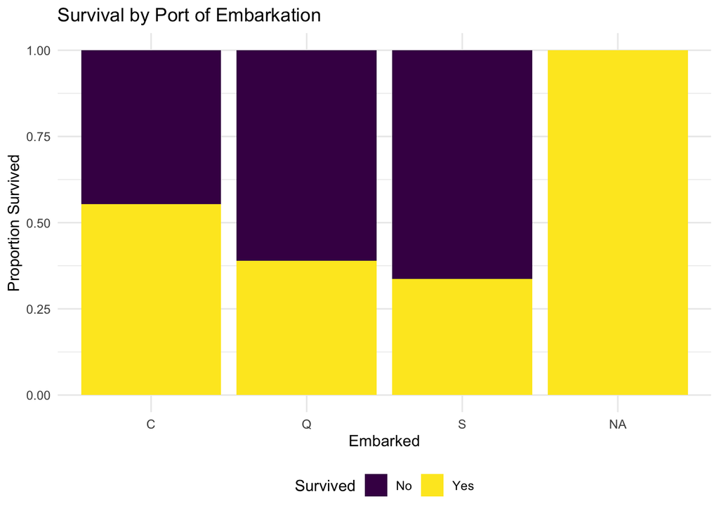

```r
ggplot(train, aes(x = Embarked, fill = factor(Survived))) +
  geom_bar(position = 'fill') +
  scale_fill_viridis_d(name = "Survived", labels = c("No", "Yes")) +
  labs(title = "Survival by Port of Embarkation", x = "Embarked", y = "Proportion Survived") +
  theme_minimal() +
  theme(legend.position = "bottom")
```

This plot shows survival proportions by port of embarkation. It provides a first look at whether embarkation port is associated with survival.

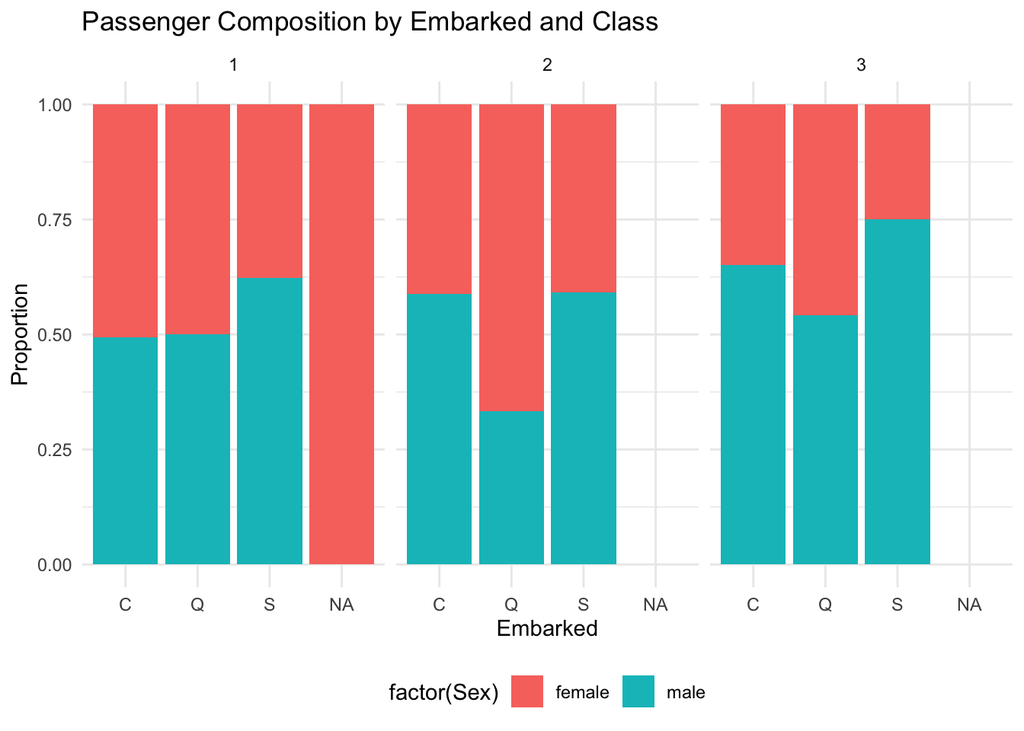

```r
ggplot(train, aes(x = Embarked, fill = factor(Sex))) +
  geom_bar(position = 'fill') +
  facet_wrap(~Pclass) +
  labs(title = "Passenger Composition by Embarked and Class", x = "Embarked", y = "Proportion") +
  theme_minimal() +
  theme(legend.position = "bottom")
```

This plot examines the composition of passengers by port, class, and sex, helping to control for confounding when interpreting survival differences by port.

## 3.2 Model: Add Embarked and Embarked*Pclass Interaction

```r
train$Embarked <- as.factor(train$Embarked)
model5 <- train(factor(Survived) ~ Pclass + Sex + Embarked, data = train, method = "glm", family = "binomial", trControl = trainControl(method = "cv", number = 5), na.action = na.omit)
model6 <- train(factor(Survived) ~ Pclass + Sex + Embarked + Pclass:Embarked, data = train, method = "glm", family = "binomial", trControl = trainControl(method = "cv", number = 5), na.action = na.omit)
cv_gain_emb <- model6$results$Accuracy - model5$results$Accuracy
imp_emb <- varImp(model6)
cv_gain_emb
```

```
[1] 0.002234495
```

```r
imp_emb
```

```
glm variable importance

                    Overall
Sexmale            100.0000
Pclass              22.2217
`Pclass:EmbarkedS`   9.2462
EmbarkedQ            1.3235
EmbarkedS            0.8214
`Pclass:EmbarkedQ`   0.0000
```

We fit models with and without the interaction between class and embarkation port, comparing cross-validation accuracy and inspecting feature importance. This helps determine if embarkation port has an effect on survival after controlling for passenger composition.